# Optimal Treatment Analysis

## Outcome Variable

**Outcome Variable:** haz

## Predictor Variables

**Intervention Variable:** gagebrth

**Adjustment Set:**

- arm
- sex
- W_mage
- meducyrs
- feducyrs
- hhwealth_quart
- single
- brthmon
- W_parity
- delta_W_mage
- delta_meducyrs
- delta_feducyrs
- delta_hhwealth_quart
- delta_single
- delta_brthmon
- delta_W_parity

## Stratifying Variables

The analysis was stratified on these variable(s):

- agecat
- studyid
- country

## Data Summary

| agecat | studyid | country | gagebrth | n_cell | n |
| --- | --- | --- | --- | --- | --- |
| Birth | ki1000108-CMC-V-BCS-2002 | INDIA | Full or late term | 57 | 90 |
| Birth | ki1000108-CMC-V-BCS-2002 | INDIA | Preterm | 10 | 90 |
| Birth | ki1000108-CMC-V-BCS-2002 | INDIA | Early term | 23 | 90 |
| Birth | ki1000108-IRC | INDIA | Full or late term | 238 | 369 |
| Birth | ki1000108-IRC | INDIA | Preterm | 36 | 369 |
| Birth | ki1000108-IRC | INDIA | Early term | 95 | 369 |
| Birth | ki1000109-EE | PAKISTAN | Full or late term | 0 | 2 |
| Birth | ki1000109-EE | PAKISTAN | Preterm | 1 | 2 |
| Birth | ki1000109-EE | PAKISTAN | Early term | 1 | 2 |
| Birth | ki1000304b-SAS-CompFeed | INDIA | Full or late term | 1 | 187 |
| Birth | ki1000304b-SAS-CompFeed | INDIA | Preterm | 171 | 187 |
| Birth | ki1000304b-SAS-CompFeed | INDIA | Early term | 15 | 187 |
| Birth | ki1017093c-NIH-Crypto | BANGLADESH | Full or late term | 7 | 27 |
| Birth | ki1017093c-NIH-Crypto | BANGLADESH | Preterm | 5 | 27 |
| Birth | ki1017093c-NIH-Crypto | BANGLADESH | Early term | 15 | 27 |
| Birth | ki1101329-Keneba | GAMBIA | Full or late term | 734 | 1515 |
| Birth | ki1101329-Keneba | GAMBIA | Preterm | 235 | 1515 |
| Birth | ki1101329-Keneba | GAMBIA | Early term | 546 | 1515 |
| Birth | ki1119695-PROBIT | BELARUS | Full or late term | 7095 | 13884 |
| Birth | ki1119695-PROBIT | BELARUS | Preterm | 472 | 13884 |
| Birth | ki1119695-PROBIT | BELARUS | Early term | 6317 | 13884 |
| Birth | ki1135781-COHORTS | GUATEMALA | Full or late term | 341 | 617 |
| Birth | ki1135781-COHORTS | GUATEMALA | Preterm | 95 | 617 |
| Birth | ki1135781-COHORTS | GUATEMALA | Early term | 181 | 617 |
| Birth | ki1135781-COHORTS | INDIA | Full or late term | 570 | 1293 |
| Birth | ki1135781-COHORTS | INDIA | Preterm | 285 | 1293 |
| Birth | ki1135781-COHORTS | INDIA | Early term | 438 | 1293 |
| Birth | ki1135781-COHORTS | PHILIPPINES | Full or late term | 1164 | 3024 |
| Birth | ki1135781-COHORTS | PHILIPPINES | Preterm | 649 | 3024 |
| Birth | ki1135781-COHORTS | PHILIPPINES | Early term | 1211 | 3024 |

[output cut: 69 more lines]

The following strata were considered:

- agecat: 24 months, studyid: ki1000108-CMC-V-BCS-2002, country: INDIA
- agecat: 24 months, studyid: ki1000108-IRC, country: INDIA
- agecat: 24 months, studyid: ki1017093c-NIH-Crypto, country: BANGLADESH
- agecat: 24 months, studyid: ki1066203-TanzaniaChild2, country: TANZANIA, UNITED REPUBLIC OF
- agecat: 24 months, studyid: ki1101329-Keneba, country: GAMBIA
- agecat: 24 months, studyid: ki1119695-PROBIT, country: BELARUS
- agecat: 24 months, studyid: ki1135781-COHORTS, country: GUATEMALA
- agecat: 24 months, studyid: ki1135781-COHORTS, country: INDIA
- agecat: 24 months, studyid: ki1135781-COHORTS, country: PHILIPPINES
- agecat: 24 months, studyid: kiGH5241-JiVitA-3, country: BANGLADESH
- agecat: 6 months, studyid: ki1000108-CMC-V-BCS-2002, country: INDIA
- agecat: 6 months, studyid: ki1000108-IRC, country: INDIA
- agecat: 6 months, studyid: ki1000109-EE, country: PAKISTAN
- agecat: 6 months, studyid: ki1000304b-SAS-CompFeed, country: INDIA
- agecat: 6 months, studyid: ki1017093c-NIH-Crypto, country: BANGLADESH
- agecat: 6 months, studyid: ki1066203-TanzaniaChild2, country: TANZANIA, UNITED REPUBLIC OF
- agecat: 6 months, studyid: ki1101329-Keneba, country: GAMBIA
- agecat: 6 months, studyid: ki1119695-PROBIT, country: BELARUS
- agecat: 6 months, studyid: ki1135781-COHORTS, country: GUATEMALA
- agecat: 6 months, studyid: ki1135781-COHORTS, country: INDIA
- agecat: 6 months, studyid: ki1135781-COHORTS, country: PHILIPPINES
- agecat: 6 months, studyid: kiGH5241-JiVitA-3, country: BANGLADESH
- agecat: Birth, studyid: ki1000108-CMC-V-BCS-2002, country: INDIA
- agecat: Birth, studyid: ki1000108-IRC, country: INDIA
- agecat: Birth, studyid: ki1000109-EE, country: PAKISTAN
- agecat: Birth, studyid: ki1000304b-SAS-CompFeed, country: INDIA
- agecat: Birth, studyid: ki1017093c-NIH-Crypto, country: BANGLADESH
- agecat: Birth, studyid: ki1101329-Keneba, country: GAMBIA
- agecat: Birth, studyid: ki1119695-PROBIT, country: BELARUS
- agecat: Birth, studyid: ki1135781-COHORTS, country: GUATEMALA
- agecat: Birth, studyid: ki1135781-COHORTS, country: INDIA
- agecat: Birth, studyid: ki1135781-COHORTS, country: PHILIPPINES
- agecat: Birth, studyid: kiGH5241-JiVitA-3, country: BANGLADESH

### Dropped Strata

Some strata were dropped due to rare outcomes:

- agecat: Birth, studyid: ki1000109-EE, country: PAKISTAN
- agecat: Birth, studyid: ki1000304b-SAS-CompFeed, country: INDIA
- agecat: 24 months, studyid: ki1066203-TanzaniaChild2, country: TANZANIA, UNITED REPUBLIC OF

## Methods Detail

We’re interested in the causal parameters $E[Y_a]$ for all values of $a \in \mathcal{A}$. These parameters represent the mean outcome if, possibly contrary to fact, we intervened to set all units to have $A=a$. Under the randomization and positivity assumptions, these are identified by the statistical parameters $\psi_a=E_W[E_{Y|A,W}(Y|A=a,W)]$. In addition, we’re interested in the mean of $Y$, $E[Y]$ under no intervention (the observed mean). We will estimate these parameters by using SuperLearner to fit the relevant likelihood factors – $E_{Y|A,W}(Y|A=a,W)$ and $p(A=a|W)$, and then updating our likelihood fit using a joint TMLE.

For unadjusted analyses ($W=\{\}$), initial likelihoods were estimated using Lrnr_glm to estimate the simple $E(Y|A)$ and Lrnr_mean to estimate $p(A)$. For adjusted analyses, a small library containing Lrnr_glmnet, Lrnr_xgboost, and Lrnr_mean was used.

Having estimated these parameters, we will then use the delta method to estimate relative risks and attributable risks relative to a prespecified baseline level of $A$.

# Results Detail

## Results Plots

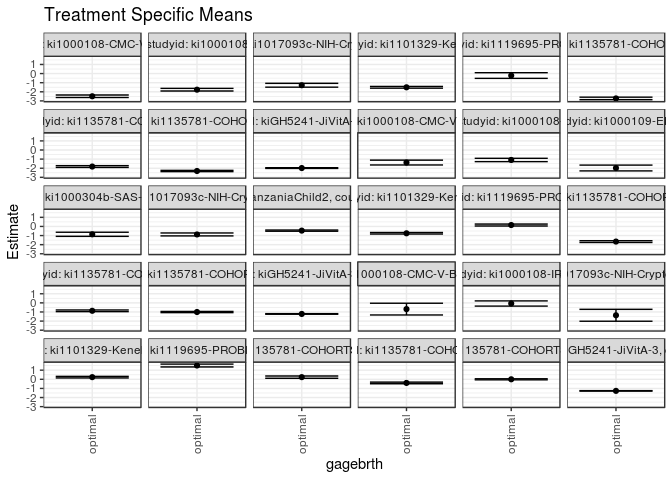

## Results Table

### Parameter: TSM

| agecat | studyid | country | intervention_level | baseline_level | estimate | ci_lower | ci_upper |
| --- | --- | --- | --- | --- | --- | --- | --- |
| Birth | ki1000108-CMC-V-BCS-2002 | INDIA | optimal | observed | -0.6853651 | -1.3286730 | -0.0420571 |
| Birth | ki1000108-IRC | INDIA | optimal | observed | -0.0699966 | -0.3564728 | 0.2164795 |
| Birth | ki1017093c-NIH-Crypto | BANGLADESH | optimal | observed | -1.3624723 | -2.0142069 | -0.7107377 |
| Birth | ki1101329-Keneba | GAMBIA | optimal | observed | 0.2367971 | 0.1499917 | 0.3236025 |
| Birth | ki1119695-PROBIT | BELARUS | optimal | observed | 1.5132971 | 1.3578009 | 1.6687934 |
| Birth | ki1135781-COHORTS | GUATEMALA | optimal | observed | 0.2370228 | 0.1123581 | 0.3616874 |
| Birth | ki1135781-COHORTS | INDIA | optimal | observed | -0.3984979 | -0.4869592 | -0.3100366 |
| Birth | ki1135781-COHORTS | PHILIPPINES | optimal | observed | 0.0009799 | -0.0573047 | 0.0592646 |
| Birth | kiGH5241-JiVitA-3 | BANGLADESH | optimal | observed | -1.2701324 | -1.2941204 | -1.2461444 |
| 6 months | ki1000108-CMC-V-BCS-2002 | INDIA | optimal | observed | -1.3771896 | -1.6421612 | -1.1122179 |
| 6 months | ki1000108-IRC | INDIA | optimal | observed | -1.0925854 | -1.2746257 | -0.9105450 |
| 6 months | ki1000109-EE | PAKISTAN | optimal | observed | -1.9771974 | -2.2954749 | -1.6589198 |
| 6 months | ki1000304b-SAS-CompFeed | INDIA | optimal | observed | -0.8625330 | -1.0869261 | -0.6381400 |
| 6 months | ki1017093c-NIH-Crypto | BANGLADESH | optimal | observed | -0.8785735 | -1.0390283 | -0.7181188 |
| 6 months | ki1066203-TanzaniaChild2 | TANZANIA, UNITED REPUBLIC OF | optimal | observed | -0.4583388 | -0.5228462 | -0.3938314 |
| 6 months | ki1101329-Keneba | GAMBIA | optimal | observed | -0.7524071 | -0.8348460 | -0.6699682 |
| 6 months | ki1119695-PROBIT | BELARUS | optimal | observed | 0.1543012 | 0.0485659 | 0.2600365 |
| 6 months | ki1135781-COHORTS | GUATEMALA | optimal | observed | -1.6608625 | -1.7584398 | -1.5632852 |
| 6 months | ki1135781-COHORTS | INDIA | optimal | observed | -0.8692179 | -0.9607416 | -0.7776942 |
| 6 months | ki1135781-COHORTS | PHILIPPINES | optimal | observed | -1.0035350 | -1.0674278 | -0.9396422 |
| 6 months | kiGH5241-JiVitA-3 | BANGLADESH | optimal | observed | -1.2159728 | -1.2476443 | -1.1843014 |
| 24 months | ki1000108-CMC-V-BCS-2002 | INDIA | optimal | observed | -2.4882871 | -2.6241582 | -2.3524159 |
| 24 months | ki1000108-IRC | INDIA | optimal | observed | -1.7676624 | -1.9128203 | -1.6225046 |
| 24 months | ki1017093c-NIH-Crypto | BANGLADESH | optimal | observed | -1.2805219 | -1.4895447 | -1.0714991 |
| 24 months | ki1101329-Keneba | GAMBIA | optimal | observed | -1.5073200 | -1.6032907 | -1.4113494 |
| 24 months | ki1119695-PROBIT | BELARUS | optimal | observed | -0.2146581 | -0.5258055 | 0.0964894 |
| 24 months | ki1135781-COHORTS | GUATEMALA | optimal | observed | -2.7270993 | -2.8642152 | -2.5899833 |
| 24 months | ki1135781-COHORTS | INDIA | optimal | observed | -1.8156289 | -1.9120739 | -1.7191839 |
| 24 months | ki1135781-COHORTS | PHILIPPINES | optimal | observed | -2.3032595 | -2.3719887 | -2.2345303 |
| 24 months | kiGH5241-JiVitA-3 | BANGLADESH | optimal | observed | -1.9812225 | -2.0230056 | -1.9394393 |

### Parameter: E(Y)

| agecat | studyid | country | intervention_level | baseline_level | estimate | ci_lower | ci_upper |
| --- | --- | --- | --- | --- | --- | --- | --- |
| Birth | ki1000108-CMC-V-BCS-2002 | INDIA | observed | observed | -0.9654444 | -1.1742112 | -0.7566777 |
| Birth | ki1000108-IRC | INDIA | observed | observed | -0.3102981 | -0.4751168 | -0.1454794 |
| Birth | ki1017093c-NIH-Crypto | BANGLADESH | observed | observed | -1.1100000 | -1.5086894 | -0.7113106 |
| Birth | ki1101329-Keneba | GAMBIA | observed | observed | 0.0288383 | -0.0354675 | 0.0931441 |
| Birth | ki1119695-PROBIT | BELARUS | observed | observed | 1.3254775 | 1.1669293 | 1.4840258 |
| Birth | ki1135781-COHORTS | GUATEMALA | observed | observed | 0.0530794 | -0.0441925 | 0.1503513 |
| Birth | ki1135781-COHORTS | INDIA | observed | observed | -0.6072158 | -0.6675691 | -0.5468624 |
| Birth | ki1135781-COHORTS | PHILIPPINES | observed | observed | -0.2492460 | -0.2884729 | -0.2100192 |
| Birth | kiGH5241-JiVitA-3 | BANGLADESH | observed | observed | -1.5660681 | -1.5858219 | -1.5463144 |
| 6 months | ki1000108-CMC-V-BCS-2002 | INDIA | observed | observed | -1.3856004 | -1.5319935 | -1.2392073 |
| 6 months | ki1000108-IRC | INDIA | observed | observed | -1.2321263 | -1.3660720 | -1.0981806 |
| 6 months | ki1000109-EE | PAKISTAN | observed | observed | -2.2004704 | -2.3234073 | -2.0775336 |
| 6 months | ki1000304b-SAS-CompFeed | INDIA | observed | observed | -1.4018312 | -1.4804646 | -1.3231978 |
| 6 months | ki1017093c-NIH-Crypto | BANGLADESH | observed | observed | -1.1986783 | -1.2700937 | -1.1272630 |
| 6 months | ki1066203-TanzaniaChild2 | TANZANIA, UNITED REPUBLIC OF | observed | observed | -0.5419570 | -0.5926042 | -0.4913098 |
| 6 months | ki1101329-Keneba | GAMBIA | observed | observed | -0.8948084 | -0.9510697 | -0.8385471 |
| 6 months | ki1119695-PROBIT | BELARUS | observed | observed | 0.1069986 | 0.0122286 | 0.2017686 |
| 6 months | ki1135781-COHORTS | GUATEMALA | observed | observed | -1.8315428 | -1.9081267 | -1.7549589 |
| 6 months | ki1135781-COHORTS | INDIA | observed | observed | -0.9630335 | -1.0220763 | -0.9039908 |
| 6 months | ki1135781-COHORTS | PHILIPPINES | observed | observed | -1.1409862 | -1.1830414 | -1.0989310 |
| 6 months | kiGH5241-JiVitA-3 | BANGLADESH | observed | observed | -1.3404486 | -1.3659169 | -1.3149804 |
| 24 months | ki1000108-CMC-V-BCS-2002 | INDIA | observed | observed | -2.5330857 | -2.6360668 | -2.4301046 |
| 24 months | ki1000108-IRC | INDIA | observed | observed | -1.7805128 | -1.8756216 | -1.6854041 |
| 24 months | ki1017093c-NIH-Crypto | BANGLADESH | observed | observed | -1.4295331 | -1.5127726 | -1.3462935 |
| 24 months | ki1101329-Keneba | GAMBIA | observed | observed | -1.5664092 | -1.6263058 | -1.5065125 |
| 24 months | ki1119695-PROBIT | BELARUS | observed | observed | -0.1314048 | -0.4282725 | 0.1654630 |
| 24 months | ki1135781-COHORTS | GUATEMALA | observed | observed | -2.8606184 | -2.9431264 | -2.7781104 |
| 24 months | ki1135781-COHORTS | INDIA | observed | observed | -1.9130810 | -1.9742771 | -1.8518850 |
| 24 months | ki1135781-COHORTS | PHILIPPINES | observed | observed | -2.3902929 | -2.4353250 | -2.3452608 |
| 24 months | kiGH5241-JiVitA-3 | BANGLADESH | observed | observed | -2.0468674 | -2.0777591 | -2.0159757 |

### Parameter: PAR

| agecat | studyid | country | intervention_level | baseline_level | estimate | ci_lower | ci_upper |
| --- | --- | --- | --- | --- | --- | --- | --- |
| Birth | ki1000108-CMC-V-BCS-2002 | INDIA | optimal | observed | -0.2800794 | -0.8981794 | 0.3380206 |
| Birth | ki1000108-IRC | INDIA | optimal | observed | -0.2403015 | -0.4935640 | 0.0129611 |
| Birth | ki1017093c-NIH-Crypto | BANGLADESH | optimal | observed | 0.2524723 | -0.3900483 | 0.8949928 |
| Birth | ki1101329-Keneba | GAMBIA | optimal | observed | -0.2079588 | -0.2747507 | -0.1411669 |
| Birth | ki1119695-PROBIT | BELARUS | optimal | observed | -0.1878196 | -0.2416041 | -0.1340351 |
| Birth | ki1135781-COHORTS | GUATEMALA | optimal | observed | -0.1839433 | -0.2734426 | -0.0944441 |
| Birth | ki1135781-COHORTS | INDIA | optimal | observed | -0.2087179 | -0.2766496 | -0.1407861 |
| Birth | ki1135781-COHORTS | PHILIPPINES | optimal | observed | -0.2502260 | -0.2983762 | -0.2020758 |
| Birth | kiGH5241-JiVitA-3 | BANGLADESH | optimal | observed | -0.2959357 | -0.3138944 | -0.2779771 |
| 6 months | ki1000108-CMC-V-BCS-2002 | INDIA | optimal | observed | -0.0084108 | -0.2456170 | 0.2287953 |
| 6 months | ki1000108-IRC | INDIA | optimal | observed | -0.1395409 | -0.2599220 | -0.0191599 |
| 6 months | ki1000109-EE | PAKISTAN | optimal | observed | -0.2232730 | -0.5387248 | 0.0921787 |
| 6 months | ki1000304b-SAS-CompFeed | INDIA | optimal | observed | -0.5392982 | -0.7593971 | -0.3191992 |
| 6 months | ki1017093c-NIH-Crypto | BANGLADESH | optimal | observed | -0.3201048 | -0.4609810 | -0.1792286 |
| 6 months | ki1066203-TanzaniaChild2 | TANZANIA, UNITED REPUBLIC OF | optimal | observed | -0.0836182 | -0.1238997 | -0.0433367 |
| 6 months | ki1101329-Keneba | GAMBIA | optimal | observed | -0.1424013 | -0.2032309 | -0.0815717 |
| 6 months | ki1119695-PROBIT | BELARUS | optimal | observed | -0.0473026 | -0.0977461 | 0.0031408 |
| 6 months | ki1135781-COHORTS | GUATEMALA | optimal | observed | -0.1706803 | -0.2415649 | -0.0997957 |
| 6 months | ki1135781-COHORTS | INDIA | optimal | observed | -0.0938157 | -0.1617938 | -0.0258376 |
| 6 months | ki1135781-COHORTS | PHILIPPINES | optimal | observed | -0.1374512 | -0.1895343 | -0.0853682 |
| 6 months | kiGH5241-JiVitA-3 | BANGLADESH | optimal | observed | -0.1244758 | -0.1445130 | -0.1044386 |
| 24 months | ki1000108-CMC-V-BCS-2002 | INDIA | optimal | observed | -0.0447986 | -0.1250521 | 0.0354548 |
| 24 months | ki1000108-IRC | INDIA | optimal | observed | -0.0128504 | -0.1161857 | 0.0904849 |
| 24 months | ki1017093c-NIH-Crypto | BANGLADESH | optimal | observed | -0.1490112 | -0.3407267 | 0.0427044 |
| 24 months | ki1101329-Keneba | GAMBIA | optimal | observed | -0.0590891 | -0.1343061 | 0.0161278 |
| 24 months | ki1119695-PROBIT | BELARUS | optimal | observed | 0.0832533 | -0.2132758 | 0.3797823 |
| 24 months | ki1135781-COHORTS | GUATEMALA | optimal | observed | -0.1335191 | -0.2450325 | -0.0220057 |
| 24 months | ki1135781-COHORTS | INDIA | optimal | observed | -0.0974521 | -0.1686553 | -0.0262490 |
| 24 months | ki1135781-COHORTS | PHILIPPINES | optimal | observed | -0.0870334 | -0.1420551 | -0.0320118 |
| 24 months | kiGH5241-JiVitA-3 | BANGLADESH | optimal | observed | -0.0656449 | -0.0913330 | -0.0399569 |